# Classification

Silvia Salini

5/3/2021

# Data

The dataset **baby_weight.sav** contains the risk factors associated with the birth of an underweight child.

- underweight: “Underweight baby”
- age: “Age of the mother”
- weight: “Weight of the mother at the last period”
- etnicity: “Ethnicity”
- smoke: “Smoker during pregnancy”
- hypertension: “History of hypertension”
- uterus: “Irritation of the uterus”

```r
library(foreign)
dat<-read.spss("baby_weight.sav", to.data.frame = TRUE, use.value.labels = FALSE)
library(dplyr)
glimpse(dat)
```

```
## Rows: 189
## Columns: 8
## $ id           <dbl> 85, 86, 87, 88, 89, 91, 92, 93, 94, 95, 96, 97, 98, 99, 1…
## $ underweight  <dbl> 0, 0, 0, 0, 0, 0, 0, 0, 0, 0, 0, 0, 0, 0, 0, 0, 0, 0, 0, …
## $ age          <dbl> 19, 33, 20, 21, 18, 21, 22, 17, 29, 26, 19, 19, 22, 30, 1…
## $ weight       <dbl> 91.0, 77.5, 52.5, 54.0, 53.5, 62.0, 59.0, 51.5, 61.5, 56.…
## $ etnicity     <dbl> 2, 3, 1, 1, 1, 3, 1, 3, 1, 1, 3, 3, 3, 3, 1, 1, 2, 1, 3, …
## $ smoke        <dbl> 0, 0, 1, 1, 1, 0, 0, 0, 1, 1, 0, 0, 0, 0, 1, 1, 0, 1, 0, …
## $ hypertension <dbl> 0, 0, 0, 0, 0, 0, 0, 0, 0, 0, 0, 0, 1, 0, 0, 0, 0, 0, 0, …
## $ uterus       <dbl> 1, 0, 0, 1, 1, 0, 0, 0, 0, 0, 0, 0, 0, 1, 0, 0, 0, 0, 1, …
```

# Outline

1. Estimate a logistic regression model of UNDERWEIGHT baby with respect to WIGHT? Compute manually the likelihood function
2. Build 2X2 contingency tables considering the UNDERWEIGHT variable and all the dichotomous variables present.
3. Waht is the RELATIVE RISK and how it is calculated?
4. What is the ODDS RATIO and how is it calculated?
5. Calculate them for the table relating to UNDERWEIGHT and SMOKING.
6. Proceed with a logistic regression model where the dependent variable is UNDERWEIGHT and the only explanatory variable is SMOKE. What is evident from the estimate of the parameter?

# Logistic regression WEIGHT

```r
lr_fit <- glm(underweight ~ weight, data = dat,
          family=binomial(link='logit'))
summary(lr_fit)
```

```
##
## Call:
## glm(formula = underweight ~ weight, family = binomial(link = "logit"),
##     data = dat)
##
## Deviance Residuals:
##     Min       1Q   Median       3Q      Max
## -1.1792  -0.9109  -0.7690   1.3080   2.1454
##
## Coefficients:
##             Estimate Std. Error z value Pr(>|z|)
## (Intercept)  1.63039    0.85850   1.899  0.05755 .
## weight      -0.03826    0.01367  -2.800  0.00511 **
## ---
## Signif. codes:  0 '***' 0.001 '**' 0.01 '*' 0.05 '.' 0.1 ' ' 1
##
## (Dispersion parameter for binomial family taken to be 1)
##
##     Null deviance: 234.67  on 188  degrees of freedom
## Residual deviance: 225.11  on 187  degrees of freedom
## AIC: 229.11
##
## Number of Fisher Scoring iterations: 4
```

```r
logLik(lr_fit)
```

```
## 'log Lik.' -112.5558 (df=2)
```

```r
(vcov = vcov(lr_fit))
```

```
##             (Intercept)        weight
## (Intercept)  0.73701588 -0.0115240509
## weight      -0.01152405  0.0001867386
```

# Plot the data and the model

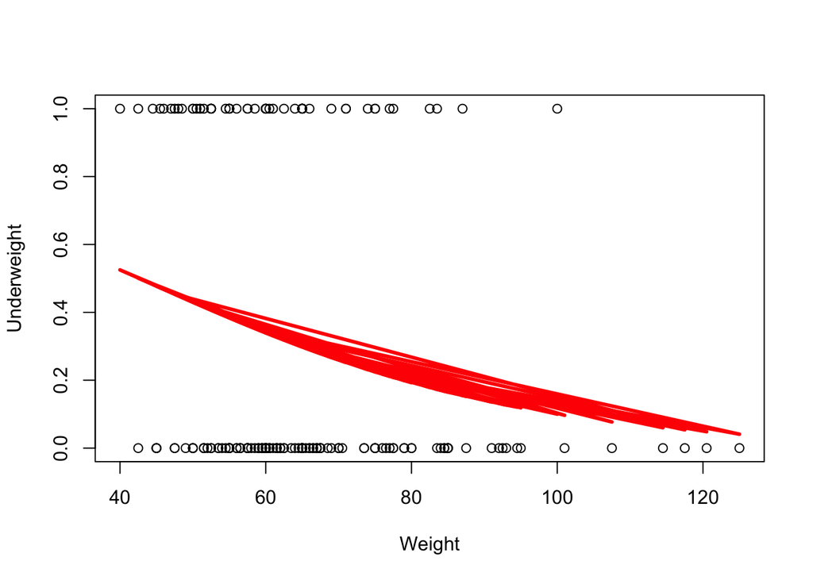

```r
plot(dat$weight, dat$underweight, , xlab="Weight", ylab="Underweight")
lines(dat$weight, lr_fit$fitted, type="l", col="red", lwd=3)
```

# direct computation of the likelihood function.

Recall that the likelihood function is defined as : $l(\beta) = \prod_{i=1}^n \pi(x_i)^{y_i}\left(1 - \pi(x_i)\right)^{1- y_i}.$ where $\pi(x_i) = \dfrac{e^{\beta_0 + \beta_1 x_i}}{1 + e^{\beta_0 + \beta_1 x_i}}$

We can define a function in R to compute the likelihood. We will rename the variables to X and Y to simplify the expression (and to make it easier to apply the likelihood function to future examples):

```r
X = dat$weight
Y = dat$underweight

likelihood = function(b){
  prod(exp(b[1] + b[2] * X[Y==1]) /(1 + exp(b[1] + b[2] * X[Y==1]))) * prod(1 /(1 + exp(b[1] + b[2] * X[Y==0])))
}
```

```r
(b = lr_fit$coefficients)
```

```
## (Intercept)      weight
##  1.63039381 -0.03826143
```

```r
likelihood(b)
```

```
## [1] 1.311109e-49
```

```r
log(likelihood(b))
```

```
## [1] -112.5558
```

```r
optim(par = c(0, 0), fn = function(x) - log(likelihood(x)))
```

```
## $par
## [1]  1.63123194 -0.03827708
##
## $value
## [1] 112.5558
##
## $counts
## function gradient
##      135       NA
##
## $convergence
## [1] 0
##
## $message
## NULL
```

```r
glm.probs=predict(lr_fit,dat,type="response")
glm.pred=ifelse(glm.probs >0.4,"1","0")
table(glm.pred,dat$underweight)
```

```
##
## glm.pred   0   1
##        0 114  39
##        1  16  20
```

```r
mean(glm.pred==dat$underweight)
```

```
## [1] 0.7089947
```

# Are Underwight and Smoke associated?

```r
mytab <- xtabs(~underweight+smoke, data=dat)
mytab
```

```
##            smoke
## underweight  0  1
##           0 85 45
##           1 29 30
```

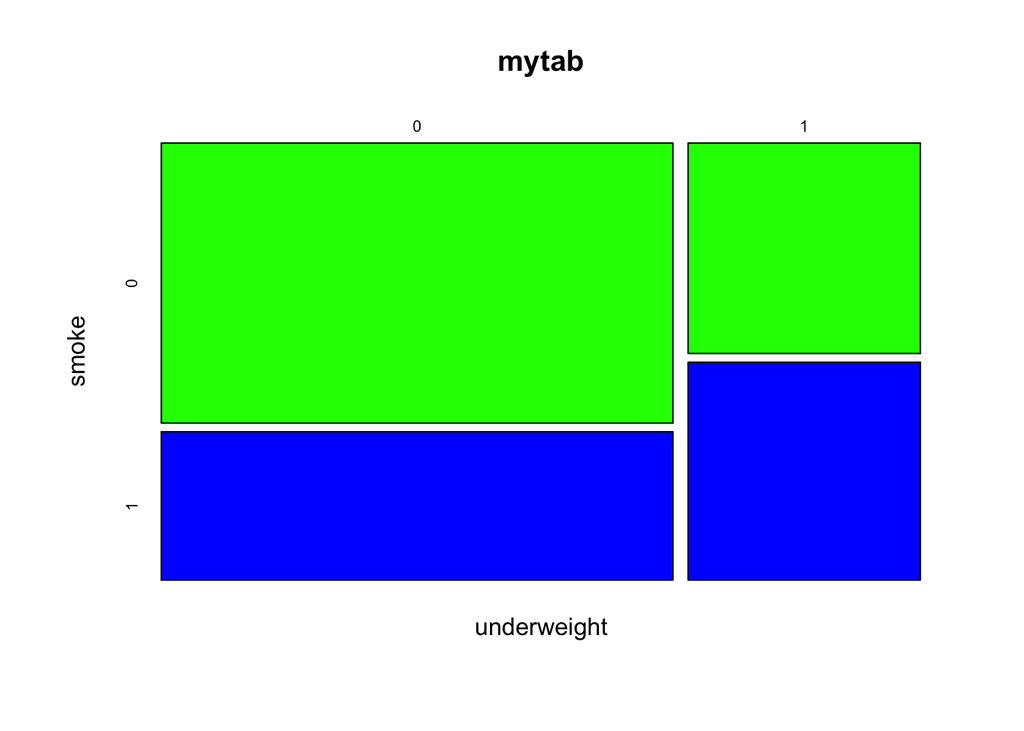

```r
plot(mytab, col=c("green","blue"))
```

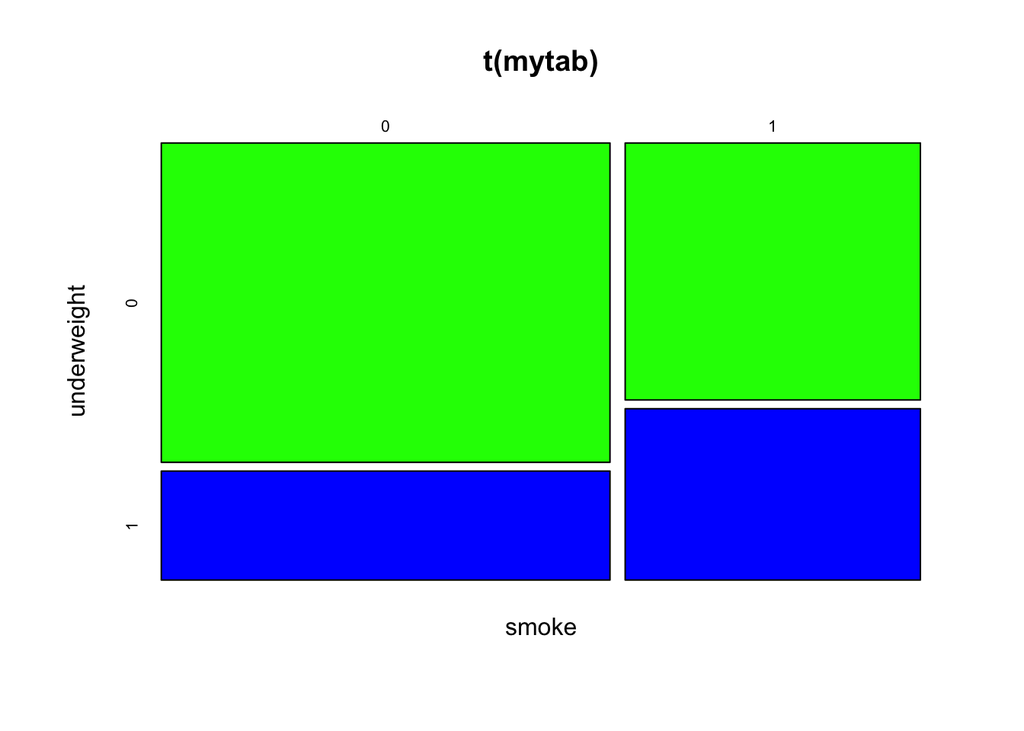

```r
plot(t(mytab), col=c("green","blue"))
```

```r
prop.table(mytab, 1) # Row Percentages
```

```
##            smoke
## underweight         0         1
##           0 0.6538462 0.3461538
##           1 0.4915254 0.5084746
```

```r
prop.table(mytab, 2) # Col Percentages
```

```
##            smoke
## underweight        0        1
##           0 0.745614 0.600000
##           1 0.254386 0.400000
```

```r
Test <- chisq.test(mytab, correct=FALSE)
Test
```

```
##
##  Pearson's Chi-squared test
##
## data:  mytab
## X-squared = 4.4672, df = 1, p-value = 0.03455
```

```r
relative_risk=(30/75)/(29/114)
relative_risk
```

```
## [1] 1.572414
```

```r
odd_under_nonsmoke=29/85
odd_under_smoke=30/45
odd_under_smoke/odd_under_nonsmoke
```

```
## [1] 1.954023
```

```r
library("epitools")
riskratio.wald(table(dat$smoke,dat$underweight))
```

```
## $data
##
##           0  1 Total
##   0      85 29   114
##   1      45 30    75
##   Total 130 59   189
##
## $measure
##    risk ratio with 95% C.I.
##     estimate   lower    upper
##   0 1.000000      NA       NA
##   1 1.572414 1.03414 2.390862
##
## $p.value
##    two-sided
##     midp.exact fisher.exact chi.square
##   0         NA           NA         NA
##   1 0.03761414   0.03829805 0.03455081
##
## $correction
## [1] FALSE
##
## attr(,"method")
## [1] "Unconditional MLE & normal approximation (Wald) CI"
```

```r
oddsratio.wald(table(dat$smoke,dat$underweight))
```

```
## $data
##
##           0  1 Total
##   0      85 29   114
##   1      45 30    75
##   Total 130 59   189
##
## $measure
##    odds ratio with 95% C.I.
##     estimate    lower    upper
##   0 1.000000       NA       NA
##   1 1.954023 1.045539 3.651901
##
## $p.value
##    two-sided
##     midp.exact fisher.exact chi.square
##   0         NA           NA         NA
##   1 0.03761414   0.03829805 0.03455081
##
## $correction
## [1] FALSE
##
## attr(,"method")
## [1] "Unconditional MLE & normal approximation (Wald) CI"
```

# Logistic regression (SMOKE)

```r
lr_fit <- glm(underweight ~ smoke, data = dat,
          family=binomial(link='logit'))
summary(lr_fit)
```

```
##
## Call:
## glm(formula = underweight ~ smoke, family = binomial(link = "logit"),
##     data = dat)
##
## Deviance Residuals:
##     Min       1Q   Median       3Q      Max
## -1.0108  -0.7662  -0.7662   1.3537   1.6546
##
## Coefficients:
##             Estimate Std. Error z value Pr(>|z|)
## (Intercept)  -1.0754     0.2151    -5.0 5.72e-07 ***
## smoke         0.6699     0.3191     2.1   0.0358 *
## ---
## Signif. codes:  0 '***' 0.001 '**' 0.01 '*' 0.05 '.' 0.1 ' ' 1
##
## (Dispersion parameter for binomial family taken to be 1)
##
##     Null deviance: 234.67  on 188  degrees of freedom
## Residual deviance: 230.25  on 187  degrees of freedom
## AIC: 234.25
##
## Number of Fisher Scoring iterations: 4
```

```r
exp(cbind(OR = coef(lr_fit), confint(lr_fit)))
```

```
##                    OR     2.5 %    97.5 %
## (Intercept) 0.3411765 0.2202136 0.5133527
## smoke       1.9540230 1.0465553 3.6682039
```

An odds ratio of 1.95 means that the odds that cases (baby undeweight) smoked was 1.95 times higher than the odds among controls (baby no underweight). Smoke might be a risk factor for baby underweight at birth.